# MEML_final

**Machine Learning for Mechanical Engineering**  
**Final Exam**  
**Thursday, 06/25/2020, 7:50 AM ~ 10:50 AM**

Instructor: Prof. Seungchul Lee  
http://iai.postech.ac.kr/  
Industrial AI Lab at POSTECH

- For your handwritten solution, scan or take a picture of them.
- For your code, only .ipynb file will be graded.
  - Please write your NAME and student ID on your .ipynb files. ex) TaewanKim_final.ipynb
- Please compress all files to make a single .zip file
  - Please write your NAME and student ID on your .zip files. ex) TaewanKim_final.zip
  - Submit it to LMS
- Do not submit a printed version of your code. It will not be graded.

# Problem 1

1) True or false for the following questions. (Correct +1, Wrong -1)

$\quad$ a. K-means clustering always gives the same result when cluster centers are randomly initalized.

$\quad$ b. K-means clustering is a suitable method for convex-shaped and different density clusters.

$\quad$ c. It is impossible to use K-means clustering when we don't know the number of clusters.

$\quad$ d. Single perceptron can solve a lineary inseperable problem with a kernel function.

$\quad$ e. Gradient descent trains neural networks to the global optimum.

2) [4pt] (Choose all the correct answers) Jonathan is tyring to solve the XOR problem using a multilayer perceptron (MLP) with ReLU activation function. However, as he trains the MLP model, the results vary at every iteration. The results are correct in some iterations, and the results are wrong at the other iterations. What is probably going wrong and what do you recommend him to do?

$\quad$ a. The training data points are not large enough. Collect a larger training data points and re-train it.

$\quad$ b. The number of perceptron layers is too large. Remove the perceptron layers and re-train it.

$\quad$ c. The number of perceptron layers is too small. Add more the perceptron layers and re-train it.

$\quad$ d. Learning rate is too high. Reduce learning rate and re-train it.

3) [2pt] Explain the difference between sigmoid (or hyperbolic tangent), and rectified linear unit (ReLU) activation functions in gradient backpropagation.

# Problem 2

[10pt] Show that minimizing the sum of squared errors maximizes the variance in the PCA.

# Problem 3

We are going to classify some fashion items by FDA (LDA). Let's load the dataset.

- Download data files
  - [data file](https://www.dropbox.com/s/pmasykp2rkf0lz4/data.npy?dl=1)
  - [data label](https://www.dropbox.com/s/3k53wau9zhwyya9/data_labels.npy?dl=1)

```python
import numpy as np
import pandas as pd
import matplotlib.pyplot as plt
%matplotlib inline
```

```python
data = np.load('./data_files/data.npy')
data_labels = np.load('./data_files/data_labels.npy')
```

```python
target_dict = {
 0: 'T-shirt/top',
 1: 'Trouser',
 2: 'Pullover',
 3: 'Dress',
 4: 'Coat',
 5: 'Sandal',
 6: 'Shirt',
 7: 'Sneaker',
 8: 'Bag',
 9: 'Ankle boot',
}
```

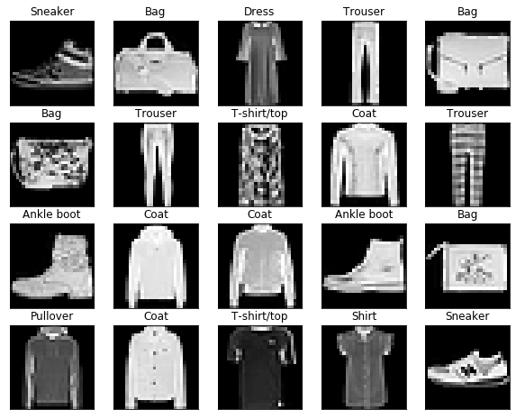

```python
plt.figure(figsize = (10,10))
for i in range(0,20):
    plt.subplot(5,5, i+1)
    plt.imshow(data[i], 'gray')
    plt.title(target_dict[(data_labels[i])])
    plt.xticks([])
    plt.yticks([])
```

1) [5pt] Choose T-shirt/top class and trouser class from 10 classes

```python
# fill out the blank

T_shirt_top_data =
Trouser_data =
```

2) [5pt] Select 1000 data from two selected classes, respectively.

```python
# Write your code here
```

```python
print(Trouser_data.shape)
```

```
(1000, 28, 28)
```

3) [5pt] Plot random images for two selected classes.

[figure not shown]

```python
# Write your code here
```

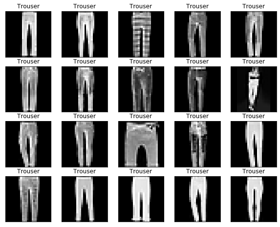

```python
# Write your code here
```

4) [5pt] Now we must select the own ‘features’ from image data to classify T_shirt_top and Trouser. The following two features are recommended

- (feature 1) The total variance pixels over the entire location.
- (feature 2) The average pixels located at the center of the image (`img[15:25,13:15]`).

```python
# fill out the blank

feature_T_shirt_top_var = np.var( ,axis = (1, 2))
feature_Trouser_var = np.var(, axis = (1, 2))
feature_T_shirt_top_mean = np.mean(,  axis = (1, 2))
feature_Trouser_mean = np.mean(, axis = (1, 2))
```

5) [2pt] The shape of each feature should be changed to (1000,1).

```python
# Write your code here
```

6) [5pt] Plot all the data in feature space

```python
# Write your code here
```

7) [10pt] Solve the problem with FDA (LDA) and visualize the histogram of data on the projected line by class.

```python
from sklearn import discriminant_analysis
```

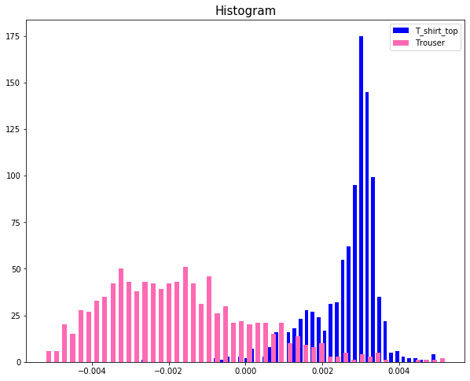

```python
# Write your code here
```

8) [10pt] Plot projection line and classification line in feature space.

```python
# Write your code here
```

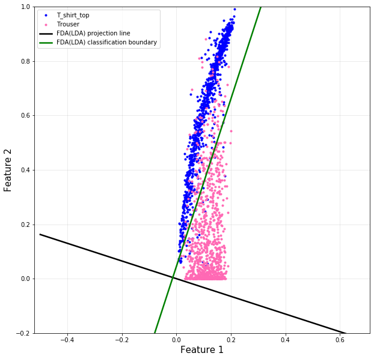

```python
plt.figure(figsize = (10, 10))
plt.plot(Theta0[:,0], Theta0[:,1], '.', color = 'b', label = 'T_shirt_top')
plt.plot(Theta1[:,0], Theta1[:,1], '.', color = 'hotpink', label ='Trouser')
plt.plot(xp, prj_yp, 'k', label = 'FDA(LDA) projection line', linewidth = 2.5)
plt.plot(xp, clf_yp, 'g', label = 'FDA(LDA) classification boundary', linewidth = 2.5)
plt.legend(fontsize = 10)
plt.grid(alpha=0.3)
plt.axis('equal')
plt.ylim([-0.2, 1])
plt.xlim([-0.05, 0.24])
plt.xlabel('Feature 1', fontsize=15)
plt.ylabel('Feature 2', fontsize=15)
plt.show()
```

# Problem 4

In this problem, we are going to classify EMNIST alphabet images. Images are 28 $\times$ 28 size and labels are 0 to 25. Let's load the dataset.

- Download data files
  - [Alphabet Handwritten_images](https://www.dropbox.com/s/1j3f8tpk9aujbkf/Alphabet_Handwritten_1000_images.npy?dl=1)
  - [Alphabet Handwritten_labels](https://www.dropbox.com/s/i562my26hlycwsu/Alphabet_Handwritten_1000_labels.npy?dl=1)

```python
import numpy as np
import matplotlib.pyplot as plt
from sklearn.model_selection import train_test_split
from sklearn.neural_network import MLPClassifier

img_file = './data_files/Alphabet_Handwritten_1000_images.npy'
lbl_file = './data_files/Alphabet_Handwritten_1000_labels.npy'

x_total = np.load(img_file) / 255
y_total = np.load(lbl_file)

x_train, _, y_train, _ = train_test_split(x_total, y_total, test_size = 0.3, random_state = 77)

print('Trainset shape:', x_train.shape, y_train.shape)

del x_total, y_total
```

```
Trainset shape: (18200, 784) (18200,)
```

1) [2pt] Plot randomly selected alphabet images for each character.

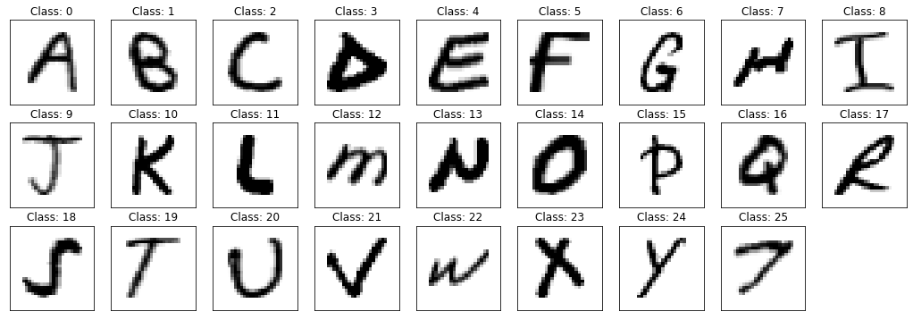

```python
# fill out the blank

plt.figure(figsize = (18, 6))
for i in range(26):
    plt.subplot(3, 9, i+1)

    idx =

    plt.imshow(x_train[idx].reshape(28, 28), 'gray_r')
    plt.title('Class: {}'.format(i))
    plt.xticks([]); plt.yticks([])
plt.show()
```

2) [3pt] Now, we are going to classify these alphabet images into two classes, consonant and vowel (A, E, I, O, U). Do re-labelling to the train labels.

```python
# fill out the blank

train_label = []

for i in y_train:
    if ''' write your code here''':
        train_label.append([1])
    else:
        train_label.append([0])

train_label = np.asarray(train_label).reshape(-1,)
```

3) [5pt] Train a MLP model that classifies 26 alphabets into 2 classes: consonant, and vowel.

Note that model paramters are

- `solver = 'sgd'`
- `hidden_layer_sizes = (300, 100,)`
- `activation = 'logistic'`
- `max_iter = 100`

Train your MLP model with randomly selected 6000 data from `x_train`.

Check your MLP model with given test data

- [test_x](https://www.dropbox.com/s/4s7ers94953hswc/test_x.npy?dl=1)
- [test_y](https://www.dropbox.com/s/zcuo1t9riucbefz/test_y.npy?dl=1)

```python
# Write your code here
```

```python
testx, testy = np.load('./data_files/test_x.npy'), np.load('./data_files/test_y.npy')
print('Accuracy : ', sum(clf.predict(testx) == testy) / len(testy) * 100)
```

```
Accuracy :  88.05
```

4) [5pt] As the dataset is biased to cosonant, the model might be trained to represent biased results. Re-train your MLP model.

Note that model paramters are

- `solver = 'sgd'`
- `hidden_layer_sizes = (300, 100,)`
- `activation = 'logistic'`
- `max_iter = 100`

Train your MLP model with equally selected 6000 data from each class .

- Train data should include 3000 consonants and 3000 vowels.

Check your MLP model with given test data

- [test_x](https://www.dropbox.com/s/4s7ers94953hswc/test_x.npy?dl=1)
- [test_y](https://www.dropbox.com/s/zcuo1t9riucbefz/test_y.npy?dl=1)

```python
# Write your code here
```

```python
testx, testy = np.load('./data_files/test_x.npy'), np.load('./data_files/test_y.npy')
print('Accuracy : ', sum(clf.predict(testx) == testy) / len(testy) * 100)
```

```
Accuracy :  91.7
```

# Problem 5

We are going to make an autoencoder model using EMNIST handwritten alphabet images.

Let's load the dataset.

- Download data files
  - [Alphabet Handwritten_images](https://www.dropbox.com/s/1j3f8tpk9aujbkf/Alphabet_Handwritten_1000_images.npy?dl=1)
  - [Alphabet Handwritten_labels](https://www.dropbox.com/s/i562my26hlycwsu/Alphabet_Handwritten_1000_labels.npy?dl=1)

```python
import numpy as np
import matplotlib.pyplot as plt
from sklearn.model_selection import train_test_split
from sklearn.neural_network import MLPClassifier
from sklearn.neural_network import MLPRegressor
from sklearn.metrics import accuracy_score
%matplotlib inline

img_file = './data_files/Alphabet_Handwritten_1000_images.npy'
lbl_file = './data_files/Alphabet_Handwritten_1000_labels.npy'

x_total = np.load(img_file)
y_total = np.load(lbl_file)

x_train, x_test, y_train, y_test = train_test_split(x_total, y_total, test_size=0.15, random_state=77)

print('Trainset shape:', x_train.shape, y_train.shape)
print('Testset shape:', x_test.shape, y_test.shape)

del x_total, y_total
```

```
Trainset shape: (22100, 784) (22100,)
Testset shape: (3900, 784) (3900,)
```

1) [6pt] Count the number of each character in trainset and plot the images in a descending order.

```python
# Write your code here
```

2) [10pt] Make your own autoencoder model using the top 3 most frequent alphabets in trainset. Set the dimension of latent space is 2.

- Dimension of latent space = 2
- The number of encoder's hidden layers = 3, (500, 300, 200)
- The number of decoder's hidden layers = 3, (500, 300, 200)
- activation = `tanh`
- solver = `adam`

```python
# write your code here
```

```python
# Shape of input and latent variable

n_input = 28*28

# Encoder structure
n_encoder1 = 500
n_encoder2 = 300
n_encoder3 = 200

n_latent = 2

# Decoder structure
n_decoder3 = 200
n_decoder2 = 300
n_decoder1 = 500
```

```python
# write your code here
```

3) [5pt] Reconstruct random images of each character from testset. (the top 3 most frequent alphabets)

```python
# fill out the blank

idxs =

for idx in idxs:
    x_reconst = reg.predict(test_x[idx].reshape(-1,784))
    plt.figure(figsize = (10,8))
    plt.subplot(1,2,1)
    plt.imshow(test_x[idx].reshape(28,28), 'gray')
    plt.title('Imput Image', fontsize = 15)
    plt.xticks([])
    plt.yticks([])
    plt.subplot(1,2,2)
    plt.imshow(x_reconst.reshape(28,28), 'gray')
    plt.title('Reconstructed Image', fontsize = 15)
    plt.xticks([])
    plt.yticks([])
    plt.show()
```

4) [10pt] Show the latent variables of the testset in 2D space.

```python
# write your code here
```

5) [10pt] Suppose we do not know the label of the test set. Do K-means clustring (with $k = 3$) on latent variables with the test set.

```python
from sklearn.cluster import KMeans

# write your code here
```

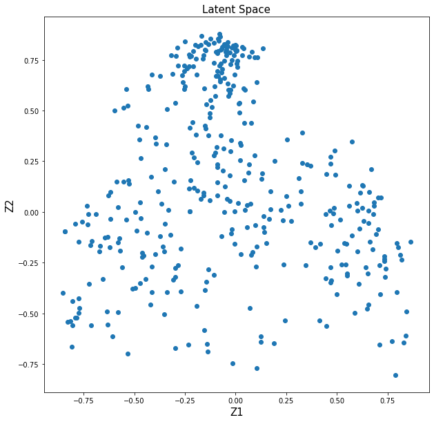

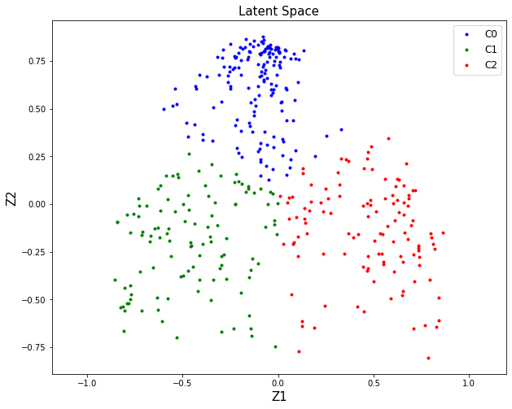

```python
plt.figure(figsize = (10,10))
plt.scatter(test_latent[:,0], test_latent[:,1])
plt.title('Latent Space', fontsize = 15)
plt.xlabel('Z1', fontsize = 15)
plt.ylabel('Z2', fontsize = 15)
plt.axis('equal')
plt.show()

plt.figure(figsize = (10,8))
plt.plot(test_latent[kmeans.labels_ == 0,0],test_latent[kmeans.labels_ == 0,1], 'b.', label = 'C0')
plt.plot(test_latent[kmeans.labels_ == 1,0],test_latent[kmeans.labels_ == 1,1], 'g.', label = 'C1')
plt.plot(test_latent[kmeans.labels_ == 2,0],test_latent[kmeans.labels_ == 2,1], 'r.', label = 'C2')
plt.axis('equal')
plt.title('Latent Space', fontsize = 15)
plt.xlabel('Z1', fontsize = 15)
plt.ylabel('Z2', fontsize = 15)
plt.legend(fontsize = 12)
plt.show()
```

6) [10pt] Generate the fake alphabets decoded from the centroids of each cluster. (The result may not be exactly the same with input image)

```python
# write your code here
```

```python
latents = np.array([[[c1x, c1y]], [[c2x, c2y]], [[c3x, c3y]]])
for latent in latents:
    reconst = decoder(latent)
    plt.figure(figsize=(16,7))
    plt.subplot(1,2,1)
    plt.plot(test_latent[kmeans.labels_ == 0,0],test_latent[kmeans.labels_ == 0,1], 'b.', label = 'C0')
    plt.plot(test_latent[kmeans.labels_ == 1,0],test_latent[kmeans.labels_ == 1,1], 'g.', label = 'C1')
    plt.plot(test_latent[kmeans.labels_ == 2,0],test_latent[kmeans.labels_ == 2,1], 'r.', label = 'C2')
    plt.scatter(latent[:,0], latent[:,1], c = 'k', marker = 'o', s = 200, label = 'new data')
    plt.title('Latent Space', fontsize = 15)
    plt.xlabel('Z1', fontsize = 15)
    plt.ylabel('Z2', fontsize = 15)
    plt.legend(loc = 2, fontsize = 12)
    plt.axis('equal')
    plt.subplot(1,2,2)
    plt.imshow(reconst.reshape(28,28), 'gray')
    plt.title('Generated Fake Image', fontsize = 15)
    plt.xticks([])
    plt.yticks([])
    plt.show()
```